# EDA with R Tutorial-UCBAdmission Project

Andy Hu

## What Is R?

R is ‘GNU S’, a freely available language and environment for statistical computing and graphics which provides a wide variety of statistical and graphical techniques: linear and nonlinear modelling, statistical tests, time series analysis, classification, clustering, etc. Please consult the R project homepage for further information. (https://cran.r-project.org/)

## What Is This File?

This file is natively available as an html file, in other words, you should be able to open it with any modern internet browser. You won’t be able to execute any R code in the browser, but all outputs are already available to you in this document.

## What Are We Accomplishing Here?

In the Microsoft Excel tutorial, we have performed a series of data munipulation and exploration tasks with Microsoft Excel. You won’t need to learn R for MPA805.As a bonus, this is to provide some additional exposure to one of the most popular and powerful statistical and graphical solutions, yet **COMPLETELY FREE**! We are recreating what we have accomplished with Microsoft Excel in R.

## Performing Tasks with R Using UCBAdmission Dataset

### Background

**Name of the dataset:** UCBAdmission

**Description:** Aggregate data on applicants to graduate school at Berkeley for the six largest departments in 1973 classified by admission and sex.

**Detailed information**: https://rdrr.io/r/datasets/UCBAdmissions.html

**The official study:** [Sex Bias in Graduate Admissions: Data from Berkeley](https://sct-prv.uab.cat/estadistica/sites/sct-prv.uab.cat.estadistica/files/3_2_Berkeley_sexBias_articleaScience.pdf)

### Import libraries

Thousands of available libraries are what make R powerful. They are voluntarily developed by enthusiasts in the R community and you guessed it, there are many many many…. many of them. Consider libraries are different add-ons that you can plug-in to your workflow to get things done faster.

**If a library is never used on the computer before**, you do need to install it first and it is super easy to do with one line of code in R. For example:

```r
#install.packages("janitor") #btw, I don't really know why it is called "janitor", probably a good data cleaning tool??...
```

After that you can just call it when you need it. I have many installed already, so I will just call all the ones needed for this tutorial.

```r
library(janitor)
library(tidyverse)
```

```r
library(ggplot2)
library(rpivotTable)
```

### Import data

In R environment, there are many illustrative datasets built in UCBAdmission is one of them.

To import data into a tabular format.

```r
df <- as.data.frame(UCBAdmissions)
```

### Explore data

To see a few of top records.

```r
head(df)
```

```
##      Admit Gender Dept Freq
## 1 Admitted   Male    A  512
## 2 Rejected   Male    A  313
## 3 Admitted Female    A   89
## 4 Rejected Female    A   19
## 5 Admitted   Male    B  353
## 6 Rejected   Male    B  207
```

To see the structure of data:

```r
str(df)
```

```
## 'data.frame':    24 obs. of  4 variables:
##  $ Admit : Factor w/ 2 levels "Admitted","Rejected": 1 2 1 2 1 2 1 2 1 2 ...
##  $ Gender: Factor w/ 2 levels "Male","Female": 1 1 2 2 1 1 2 2 1 1 ...
##  $ Dept  : Factor w/ 6 levels "A","B","C","D",..: 1 1 1 1 2 2 2 2 3 3 ...
##  $ Freq  : num  512 313 89 19 353 207 17 8 120 205 ...
```

### Create frequency and relative frequency tables

To create frequency tables by Gender and Admit

```r
admit_gender_pivot <- df %>%
  group_by(Admit, Gender) %>%
  summarise(Freq_Agg = sum(Freq)) %>%
  pivot_wider(names_from = Admit, values_from = Freq_Agg)
admit_gender_pivot
```

```
## # A tibble: 2 x 3
##   Gender Admitted Rejected
##   <fct>     <dbl>    <dbl>
## 1 Male       1198     1493
## 2 Female      557     1278
```

To add totals, row/column titles:

```r
admit_gender_pivot_full <- admit_gender_pivot %>%
  adorn_totals(where = c("row", "col")) %>%
  adorn_title(placement = "combined", row_name = 'Gender', col_name = 'Admit')
admit_gender_pivot_full
```

```
##   Gender/Admit Admitted Rejected Total
## 1         Male     1198     1493  2691
## 2       Female      557     1278  1835
## 3        Total     1755     2771  4526
```

To see % of admission to gender total by each gender:

```r
admit_gender_pivot_pct <- admit_gender_pivot %>%
  adorn_percentages("row") %>%
  adorn_pct_formatting(digits = 2)
admit_gender_pivot_pct
```

```
##  Gender Admitted Rejected
##    Male   44.52%   55.48%
##  Female   30.35%   69.65%
```

Add row/column titles:

```r
admit_gender_pivot_pct_full <- admit_gender_pivot %>%
  adorn_title(placement = "combined", row_name = 'Gender', col_name = 'Admit')
admit_gender_pivot_pct_full
```

```
##   Gender/Admit Admitted Rejected
## 1         Male     1198     1493
## 2       Female      557     1278
```

### Create bar plots for the relative frequency table

```r
admit_gender_pct <- admit_gender_pivot_pct %>%
  pivot_longer(cols = c(Admitted, Rejected), names_to = "Admit", values_to = "Rel_Freq")
admit_gender_pct
```

```
## # A tibble: 4 x 3
##   Gender Admit    Rel_Freq
##   <fct>  <chr>    <chr>
## 1 Male   Admitted 44.52%
## 2 Male   Rejected 55.48%
## 3 Female Admitted 30.35%
## 4 Female Rejected 69.65%
```

There are layers when graphing with ggplot libaray, the beginning layers are the canvas and each axis assignment. You won’t be able to see Gender yet, because that will be shown as a different color when the plot is actually made and we are not there yet.

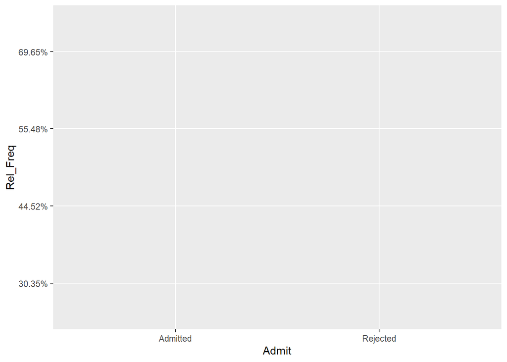

```r
ggplot(admit_gender_pct, mapping = aes(x=Admit, y=Rel_Freq, fill=Gender))
```

3rd layer is to plot the barplot for relative frequency

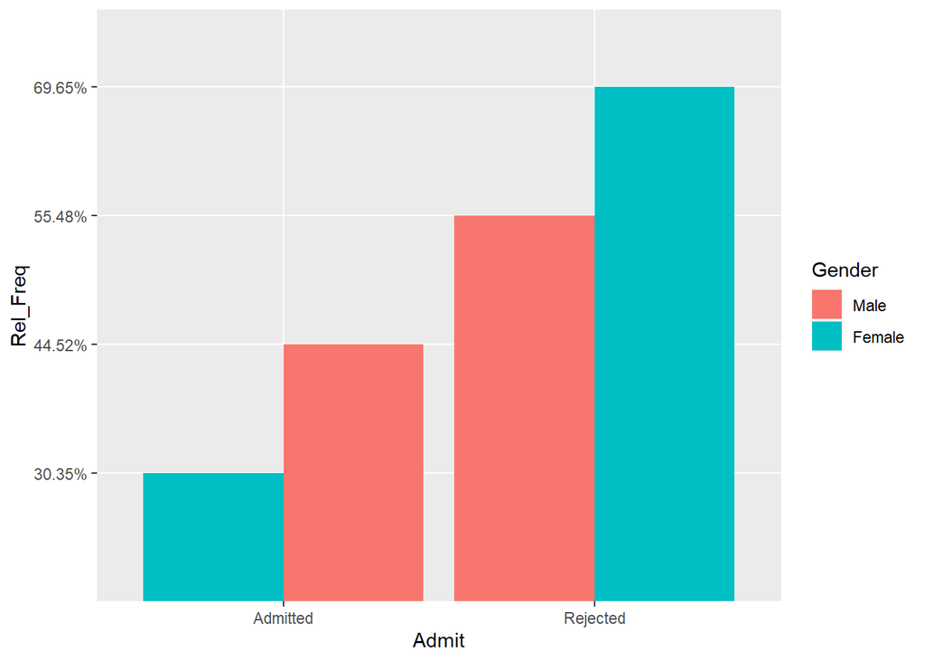

```r
ggplot(admit_gender_pct, mapping = aes(x=Admit, y=Rel_Freq, fill=Gender))+
  geom_bar(stat="identity", position = 'dodge')
```

To demo manually change category colours

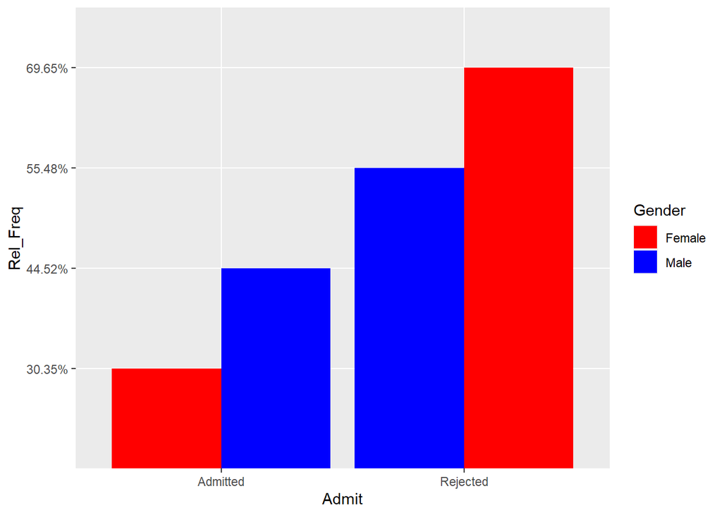

```r
ggplot(admit_gender_pct, mapping = aes(x=Admit, y=Rel_Freq, fill=Gender))+
  geom_bar(stat="identity", position = 'dodge')+
  scale_fill_manual(values = c("Female" = "red", "Male" = "blue"))
```

To add title for the barplot

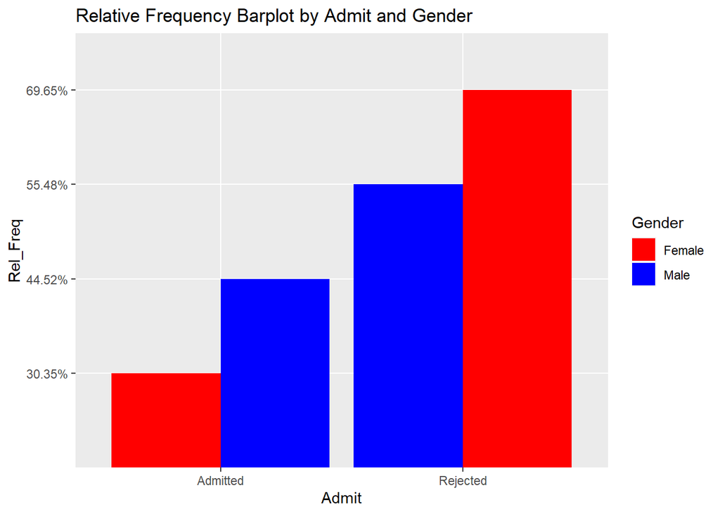

```r
ggplot(admit_gender_pct, mapping = aes(x=Admit, y=Rel_Freq, fill=Gender))+
  geom_bar(stat="identity", position = 'dodge')+
  scale_fill_manual(values = c("Female" = "red", "Male" = "blue"))+
  ggtitle("Relative Frequency Barplot by Admit and Gender")
```

To add data labels to each bar:

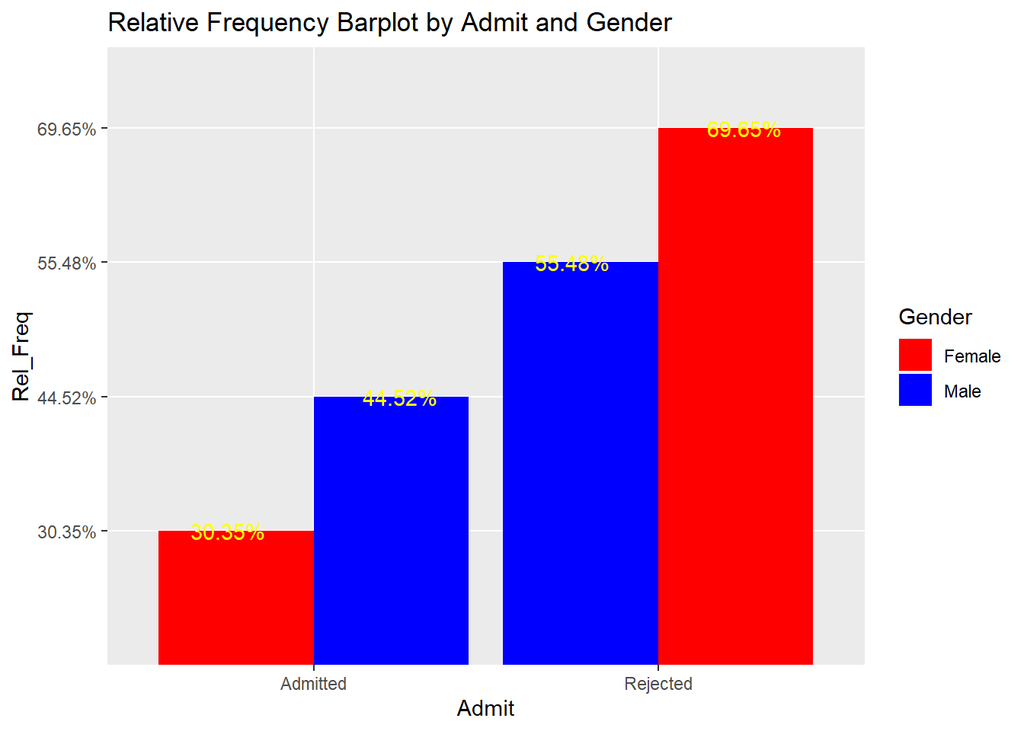

```r
ggplot(admit_gender_pct, mapping = aes(x=Admit, y=Rel_Freq, fill=Gender))+
  geom_bar(stat="identity", position = 'dodge')+
  geom_text(aes(label = Rel_Freq), colour = "yellow", position = position_dodge(width = 1), )+
  scale_fill_manual(values = c("Female" = "red", "Male" = "blue"))+
  ggtitle("Relative Frequency Barplot by Admit and Gender")
```

### Create relative frequency tables for each of the department

We repeat what we have done in “creating frequency and relative frequency table” section, but for each of the department

```r
admit_gender_pivot_DpetA <- df %>%
  filter(Dept=="A") %>%
  group_by(Admit, Gender) %>%
  summarise(Freq_Agg = sum(Freq)) %>%
  pivot_wider(names_from = Admit, values_from = Freq_Agg)
admit_gender_pivot_DpetA
```

```
## # A tibble: 2 x 3
##   Gender Admitted Rejected
##   <fct>     <dbl>    <dbl>
## 1 Male        512      313
## 2 Female       89       19
```

Then similar to above

```r
admit_gender_pivot_DpetA %>%
  adorn_percentages("row") %>%
  adorn_pct_formatting(digits = 2) %>%
  adorn_title(placement = "combined", row_name = "Gender", col_name = "Admit")
```

```
##   Gender/Admit Admitted Rejected
## 1         Male   62.06%   37.94%
## 2       Female   82.41%   17.59%
```

A good thing here is that, while we are programming anyways, why not automating things?

```r
c(unique(df$Dept))
```

```
## [1] A B C D E F
## Levels: A B C D E F
```

```r
x <- unique(df$Dept)

for (a in x){
  admit_gender_pivot_Dpet <- df %>%
  filter(Dept==a) %>%
  group_by(Admit, Gender) %>%
  summarise(Freq_Agg = sum(Freq)) %>%
  pivot_wider(names_from = Admit, values_from = Freq_Agg) %>%
  adorn_percentages("row") %>%
  adorn_pct_formatting(digits = 2) %>%
  adorn_title(placement = "combined", row_name = "Gender", col_name = "Admit")
  print(admit_gender_pivot_Dpet)
}
```

```
##   Gender/Admit Admitted Rejected
## 1         Male   62.06%   37.94%
## 2       Female   82.41%   17.59%
##   Gender/Admit Admitted Rejected
## 1         Male   63.04%   36.96%
## 2       Female   68.00%   32.00%
##   Gender/Admit Admitted Rejected
## 1         Male   36.92%   63.08%
## 2       Female   34.06%   65.94%
##   Gender/Admit Admitted Rejected
## 1         Male   33.09%   66.91%
## 2       Female   34.93%   65.07%
##   Gender/Admit Admitted Rejected
## 1         Male   27.75%   72.25%
## 2       Female   23.92%   76.08%
##   Gender/Admit Admitted Rejected
## 1         Male    5.90%   94.10%
## 2       Female    7.04%   92.96%
```

### Create a series of barplot for relative frequencies of admission by gender given a department

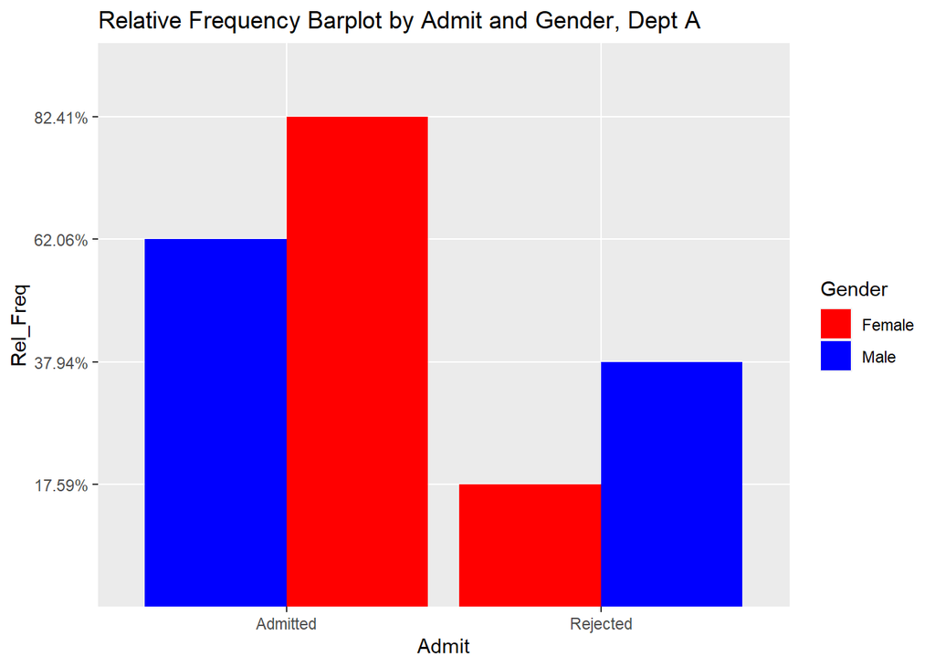

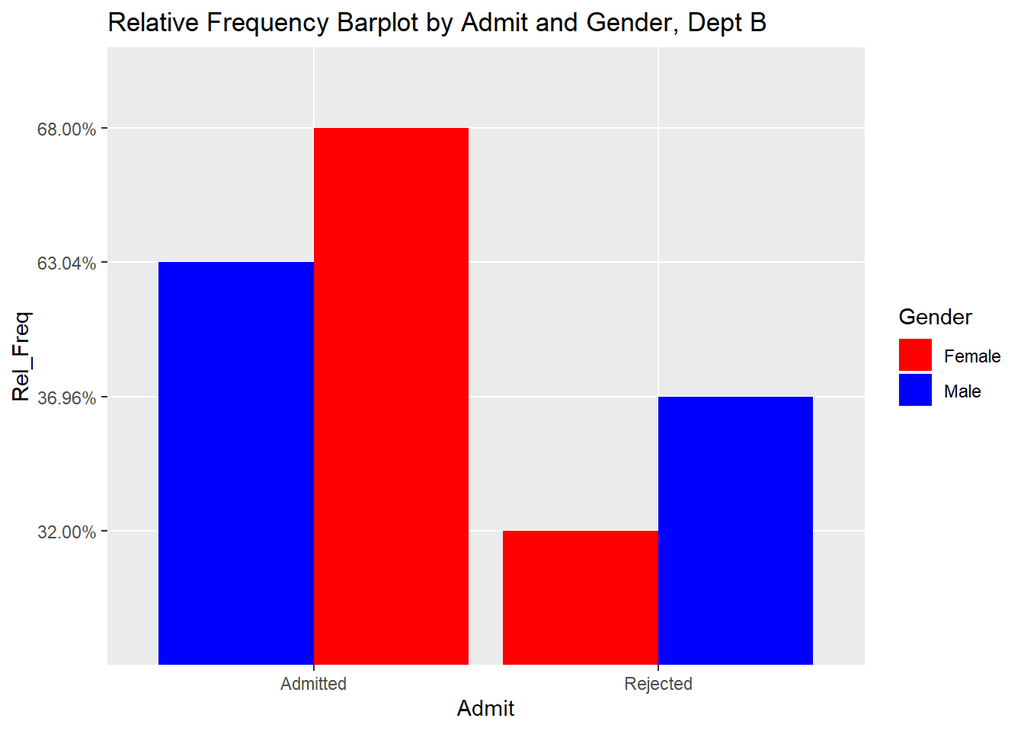

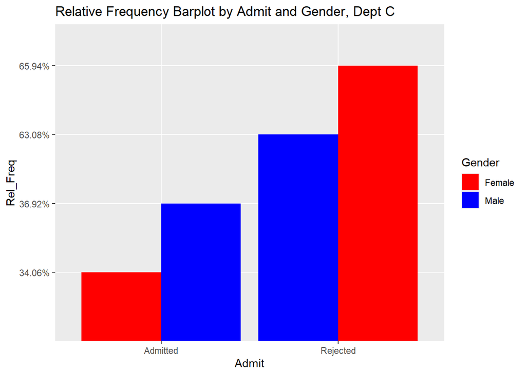

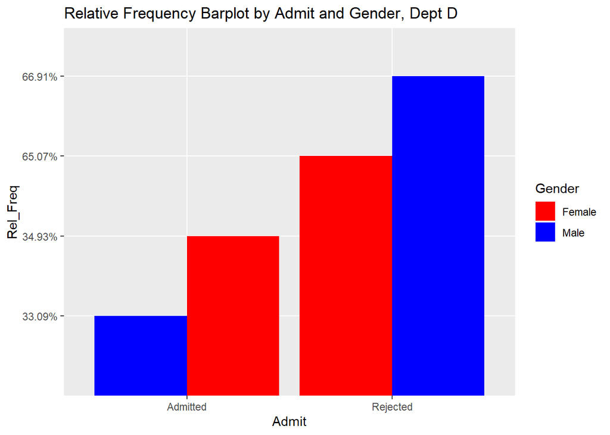

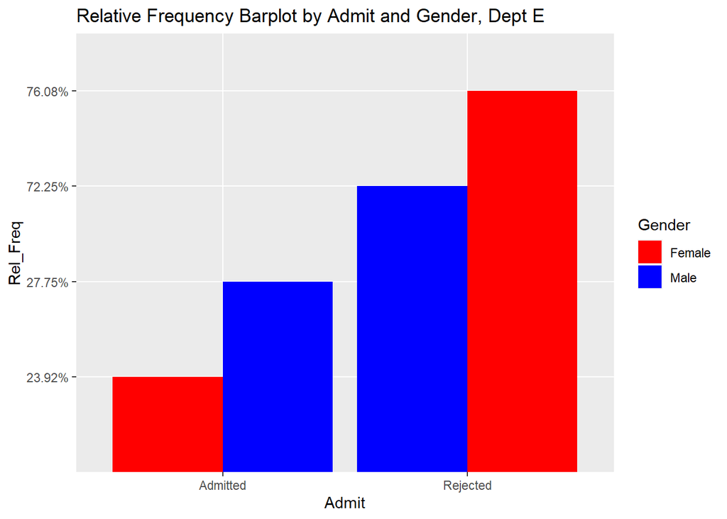

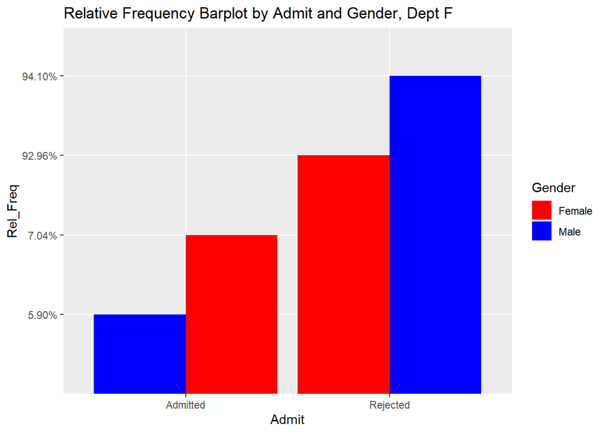

```r
x <- unique(df$Dept)

for (a in x){
  admit_gender_pivot_Dpet_Barplot <- df %>%
  filter(Dept==a) %>%
  group_by(Admit, Gender) %>%
  summarise(Freq_Agg = sum(Freq)) %>%
  pivot_wider(names_from = Admit, values_from = Freq_Agg) %>%
  adorn_percentages("row") %>%
  adorn_pct_formatting(digits = 2) %>%
  pivot_longer(cols = c(Admitted, Rejected), names_to = "Admit", values_to = "Rel_Freq") %>%
  ggplot(mapping = aes(x=Admit, y=Rel_Freq, fill=Gender))+
  geom_bar(stat="identity", position = 'dodge')+
  scale_fill_manual(values = c("Female" = "red", "Male" = "blue"))+
  ggtitle(paste("Relative Frequency Barplot by Admit and Gender, Dept", a))
  print(admit_gender_pivot_Dpet_Barplot)
}
```

#### A better way to achieve the same would be the following:

This part is interesting: the relative frequency that we are seeking is each Freq out of **total applicants ofa particular gender to a particular Dept**. Therefore, to get this subtotal in R, like before, we use group_by function (dplyr, part of tidyverse library) to find proper granularity level that we need. In this case, we need to group Dept and Gender.

```r
df_subtotal <- df %>%
  group_by(Dept, Gender) %>%
  mutate("Freq_subtotal" = sum(Freq))
df_subtotal
```

```
## # A tibble: 24 x 5
## # Groups:   Dept, Gender [12]
##    Admit    Gender Dept   Freq Freq_subtotal
##    <fct>    <fct>  <fct> <dbl>         <dbl>
##  1 Admitted Male   A       512           825
##  2 Rejected Male   A       313           825
##  3 Admitted Female A        89           108
##  4 Rejected Female A        19           108
##  5 Admitted Male   B       353           560
##  6 Rejected Male   B       207           560
##  7 Admitted Female B        17            25
##  8 Rejected Female B         8            25
##  9 Admitted Male   C       120           325
## 10 Rejected Male   C       205           325
## # ... with 14 more rows
```

One more inch to go to create the Rel_Freq itself

```r
df_rf <- df_subtotal %>%
  group_by(Dept, Gender) %>%
  mutate("Rel_Freq" = Freq/sum(Freq))
df_rf
```

```
## # A tibble: 24 x 6
## # Groups:   Dept, Gender [12]
##    Admit    Gender Dept   Freq Freq_subtotal Rel_Freq
##    <fct>    <fct>  <fct> <dbl>         <dbl>    <dbl>
##  1 Admitted Male   A       512           825    0.621
##  2 Rejected Male   A       313           825    0.379
##  3 Admitted Female A        89           108    0.824
##  4 Rejected Female A        19           108    0.176
##  5 Admitted Male   B       353           560    0.630
##  6 Rejected Male   B       207           560    0.370
##  7 Admitted Female B        17            25    0.68
##  8 Rejected Female B         8            25    0.32
##  9 Admitted Male   C       120           325    0.369
## 10 Rejected Male   C       205           325    0.631
## # ... with 14 more rows
```

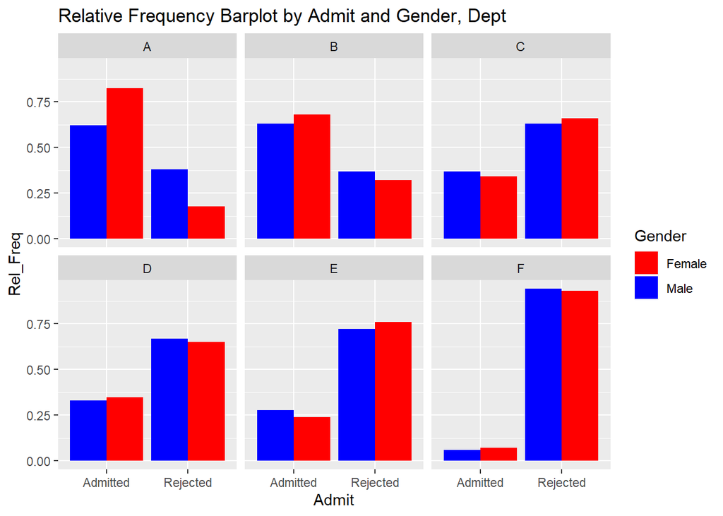

```r
ggplot(df_rf, mapping = aes(x=Admit, y=Rel_Freq, fill=Gender))+
  geom_bar(stat="identity", position = "dodge")+
  scale_fill_manual(values = c("Female" = "red", "Male" = "blue"))+
  facet_wrap(~ Dept)+
  ggtitle("Relative Frequency Barplot by Admit and Gender, Dept")
```

### Pivot Chart in R (rpivotTable), so to speak….

```r
rpivotTable(data = df_rf, cols = c("Dept", "Admit"), rows = "Gender", vals = "Rel_Freq", aggregatorName = "Sum", rendererName = "Bar Chart")
```

[interactive table not shown]